# Assignment_3_Slamanig_Klager

##### 3.5.2. call clingo with ctl.load() and ctl.solve() (Version 2)

```python
import clingo
import numpy as np

ctl = clingo.Control()
ctl.load('tsp.lp')
ctl.load('worldcities_medium.lp')
ctl.ground([("base", [])])
# ctl.solve(on_model=on_model)
models = []

# call the solver and store all formatted models
# as output by clingo in the list models:
with ctl.solve(yield_=True) as handle:
    for model in handle:
        models.append(format(model))
print("Optimal cost (= minimal distance):", model.cost, "km")
#Store shortest distance in variable (needed later)
optimalcost = model.cost
#only print the last model, which is the optimal solution
#print(models[-1],'\n\n')
#print(models[-1])

m = str(models[-1]).split(' ')
#remove all elements that do not start with travel
m = [x for x in m if x.startswith('travel')]
print("Edges considered for optimal route: \n", m)
```

```
Optimal cost (= minimal distance): [1048] km
Edges considered for optimal route:
 ['travel(kremsanderdonau,steyr)', 'travel(lustenau,dornbirn)', 'travel(innsbruck,klagenfurt)', 'travel(steyr,salzburg)', 'travel(klagenfurt,kremsanderdonau)', 'travel(dornbirn,innsbruck)', 'travel(salzburg,lustenau)']
```

#### 3.6. Print solution on a map to visualize the optimal route

For this, we need to process our result string with the edges from the optimal route to retrieve the city names again. Then, we go back to the initial data frame to access all coordinates from these cities. By using the folium library, we then add all cities as markers and draw PolyLines between the edges from the hamilton cycle. As a result, we receive a map with the optimized route for our traveling salesman problem and also the total distance covered.

```python
import pandas as pd
#Helper functions to retrieve city names and coordinates from the result and the initial df
def split_strings(arr):
    from_list = []
    to_list = []
    for s in arr:
        s = s.replace("travel(", "")
        s = s.replace(")", "")
        from_list.append(s.split(",")[0])
        to_list.append(s.split(",")[1])
    df = pd.DataFrame({"From": from_list, "To": to_list})
    return df

dfresult = split_strings(m)
# locate from and to in df and add lat and lng for each city as new columns in dfresult
dfresult['from_lat'] = dfresult['From'].map(df.set_index('city_ascii')['lat'])
dfresult['from_lng'] = dfresult['From'].map(df.set_index('city_ascii')['lng'])
dfresult['to_lat'] = dfresult['To'].map(df.set_index('city_ascii')['lat'])
dfresult['to_lng'] = dfresult['To'].map(df.set_index('city_ascii')['lng'])
dfresult
```

|  | From | To | from_lat | from_lng | to_lat | to_lng |
| --- | --- | --- | --- | --- | --- | --- |
| 0 | kremsanderdonau | steyr | 48.4167 | 15.6167 | 48.0500 | 14.4167 |
| 1 | lustenau | dornbirn | 47.4271 | 9.6711 | 47.4167 | 9.7500 |
| 2 | innsbruck | klagenfurt | 47.2683 | 11.3933 | 46.6167 | 14.3000 |
| 3 | steyr | salzburg | 48.0500 | 14.4167 | 47.7972 | 13.0477 |
| 4 | klagenfurt | kremsanderdonau | 46.6167 | 14.3000 | 48.4167 | 15.6167 |
| 5 | dornbirn | innsbruck | 47.4167 | 9.7500 | 47.2683 | 11.3933 |
| 6 | salzburg | lustenau | 47.7972 | 13.0477 | 47.4271 | 9.6711 |

```python
import folium
#Helper function to add markers and lines to the map
def addMarkersAndLines(df, map_obj):
    # iterate through the rows of your dataframe
    for i, row in df.iterrows():
    # make first city a different color
        if i == 0:
            folium.Marker([row['from_lat'], row['from_lng']], popup=row['From'], icon=folium.Icon(color='green')).add_to(map_obj)
        else:
            folium.Marker([row['from_lat'], row['from_lng']], popup=row['From']).add_to(map_obj)
        # add a PolyLine for each row to the map object
        folium.PolyLine([[ row['from_lat'], row['from_lng']], [row['to_lat'], row['to_lng']]], color="red", weight=2.5, opacity=1).add_to(map_obj)
    return map_obj
```

```python
dfresult
```

|  | From | To | from_lat | from_lng | to_lat | to_lng |
| --- | --- | --- | --- | --- | --- | --- |
| 0 | kremsanderdonau | steyr | 48.4167 | 15.6167 | 48.0500 | 14.4167 |
| 1 | lustenau | dornbirn | 47.4271 | 9.6711 | 47.4167 | 9.7500 |
| 2 | innsbruck | klagenfurt | 47.2683 | 11.3933 | 46.6167 | 14.3000 |
| 3 | steyr | salzburg | 48.0500 | 14.4167 | 47.7972 | 13.0477 |
| 4 | klagenfurt | kremsanderdonau | 46.6167 | 14.3000 | 48.4167 | 15.6167 |
| 5 | dornbirn | innsbruck | 47.4167 | 9.7500 | 47.2683 | 11.3933 |
| 6 | salzburg | lustenau | 47.7972 | 13.0477 | 47.4271 | 9.6711 |

## IMPORTANT NOTE: Running the map on the jupyter hub

We tested it ourselves and on anaconda and localhost it was running. Yet sometimes it can happen that the kernel crashes on the jupyter hub. If this happens, try restarting it again and run all cells. Usually it should work then. In case it doesn't work: This is how a solution should look like with the code below (screenshot taken from another randomized sample than the code above):

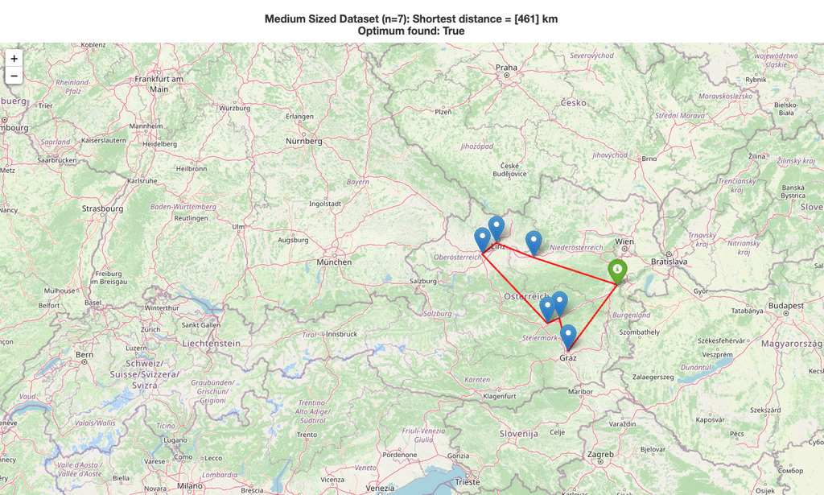

```python
import folium
#Showing the map
map_object = folium.Map(location=[47.75588839550415, 12.843425177147688], zoom_start=7)
map_object = addMarkersAndLines(dfresult, map_object)
#add heading to the map
# Add a title to the map
print("\n\nShortest distance of medium sized sample (n=7):", optimalcost,"KM")

map_object
```

```
Shortest distance of medium sized sample (n=7): [1048] KM
```

[interactive chart not shown]